# Personal Data Project

# Multiple Regression: Country Score versus GDP per capita **and** corruption perception within the country

## 1. Exploratory Data Analysis

```r
HapinessReport <- HapinessReport %>%
  mutate(Corruption = as.factor(Corruption))

HapinessReport %>%
  select(`Overall rank`, Score, `GDP per capita`, Corruption)
```

| Overall rank | Score | GDP per capita | Corruption |
| --- | --- | --- | --- |
| 1 | 7.769 | 1.340 | High |
| 2 | 7.600 | 1.383 | High |
| 3 | 7.554 | 1.488 | High |
| 4 | 7.494 | 1.380 | Low |
| 5 | 7.488 | 1.396 | Medium |
| 6 | 7.480 | 1.452 | High |
| 7 | 7.343 | 1.387 | High |
| 8 | 7.307 | 1.303 | High |
| 9 | 7.278 | 1.365 | Medium |
| 10 | 7.246 | 1.376 | Medium |

[output cut: 146 more lines]

```r
HapinessReport %>% glimpse()
```

```
Rows: 156
Columns: 10
$ `Overall rank`                 <dbl> 1, 2, 3, 4, 5, 6, 7, 8, 9, 10, 11, 12, 13, 14, 15, 16, 17, 18, 19, 20, …
$ `Country or region`            <chr> "Finland", "Denmark", "Norway", "Iceland", "Netherlands", "Switzerland"…
$ Score                          <dbl> 7.769, 7.600, 7.554, 7.494, 7.488, 7.480, 7.343, 7.307, 7.278, 7.246, 7…
$ `GDP per capita`               <dbl> 1.340, 1.383, 1.488, 1.380, 1.396, 1.452, 1.387, 1.303, 1.365, 1.376, 1…
$ `Social support`               <dbl> 1.587, 1.573, 1.582, 1.624, 1.522, 1.526, 1.487, 1.557, 1.505, 1.475, 1…
$ `Healthy life expectancy`      <dbl> 0.986, 0.996, 1.028, 1.026, 0.999, 1.052, 1.009, 1.026, 1.039, 1.016, 1…
$ `Freedom to make life choices` <dbl> 0.596, 0.592, 0.603, 0.591, 0.557, 0.572, 0.574, 0.585, 0.584, 0.532, 0…
$ Generosity                     <dbl> 0.153, 0.252, 0.271, 0.354, 0.322, 0.263, 0.267, 0.330, 0.285, 0.244, 0…
$ `Perceptions of corruption`    <dbl> 0.393, 0.410, 0.341, 0.118, 0.298, 0.343, 0.373, 0.380, 0.308, 0.226, 0…
$ Corruption                     <fct> High, High, High, Low, Medium, High, High, High, Medium, Medium, Medium…
```

```r
HapinessReport %>%
  sample_n(size = 5)
```

| Overall rank | Country or region | Score | GDP per capita | Social support | Healthy life expectancy | Freedom to make life choices | Generosity | Perceptions of corruption | Corruption |
| --- | --- | --- | --- | --- | --- | --- | --- | --- | --- |
| 41 | Uzbekistan | 6.174 | 0.745 | 1.529 | 0.756 | 0.631 | 0.322 | 0.240 | Medium |
| 113 | Namibia | 4.639 | 0.879 | 1.313 | 0.477 | 0.401 | 0.070 | 0.056 | Low |
| 138 | Zambia | 4.107 | 0.578 | 1.058 | 0.426 | 0.431 | 0.247 | 0.087 | Low |
| 122 | Mauritania | 4.490 | 0.570 | 1.167 | 0.489 | 0.066 | 0.106 | 0.088 | Low |
| 49 | Cyprus | 6.046 | 1.263 | 1.223 | 1.042 | 0.406 | 0.190 | 0.041 | Low |

```r
HapinessReport$Corruption %>% levels()
```

```
[1] "High"   "Low"    "Medium"
```

### (ii) Compute summary statistics

```r
HapinessReport %>% select(Score, `GDP per capita`, Corruption ) %>% skim()
```

```
── Data Summary ────────────────────────
                           Values
Name                       Piped data
Number of rows             156
Number of columns          3
_______________________
Column type frequency:
  factor                   1
  numeric                  2
________________________
Group variables            None
```

|  | skim_variable | n_missing | complete_rate | ordered | n_unique | top_counts |
| --- | --- | --- | --- | --- | --- | --- |
| 1 | Corruption | 0 | 1 | FALSE | 3 | Low: 131, Med: 17, Hig: 8 |

|  | skim_variable | n_missing | complete_rate | mean | sd | p0 | p25 | p50 | p75 | p100 | hist |
| --- | --- | --- | --- | --- | --- | --- | --- | --- | --- | --- | --- |
| 1 | Score | 0 | 1 | 5.4070962 | 1.1131199 | 2.853 | 4.54450 | 5.3795 | 6.1845 | 7.769 | ▂▇▇▇▃ |
| 2 | GDP per capita | 0 | 1 | 0.9051474 | 0.3983895 | 0.000 | 0.60275 | 0.9600 | 1.2325 | 1.684 | ▃▅▇▇▃ |

```r
HapinessReport %>%
  group_by(Corruption) %>%
  get_correlation(formula = `GDP per capita` ~ Score )
```

| Corruption | cor |
| --- | --- |
| High | 0.8806697 |
| Low | 0.7488200 |
| Medium | 0.8362691 |

### (iii) Create data visualisations

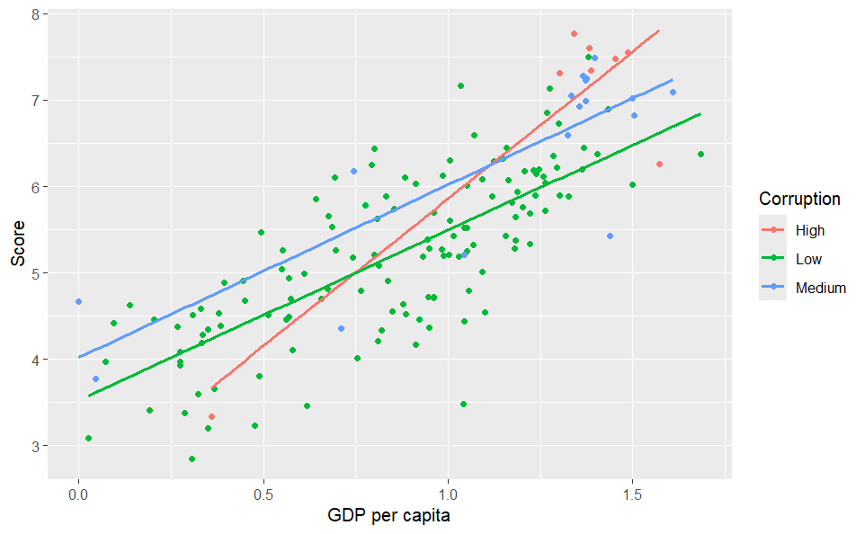

```r
plot_interaction <- HapinessReport %>%
  ggplot(aes(x = `GDP per capita`, y = Score, color = Corruption)) +
  geom_point()  +
  geom_smooth(method = "lm", se = FALSE)

plot_interaction
```

## 2. Multiple Linear Regression

### (a) Parallel slopes model

The geom_smooth() function of ggplot2 does not offer a convenient function for this. So, we make use of the special purpose function called geom_parallel_slopes() from the moderndive package.

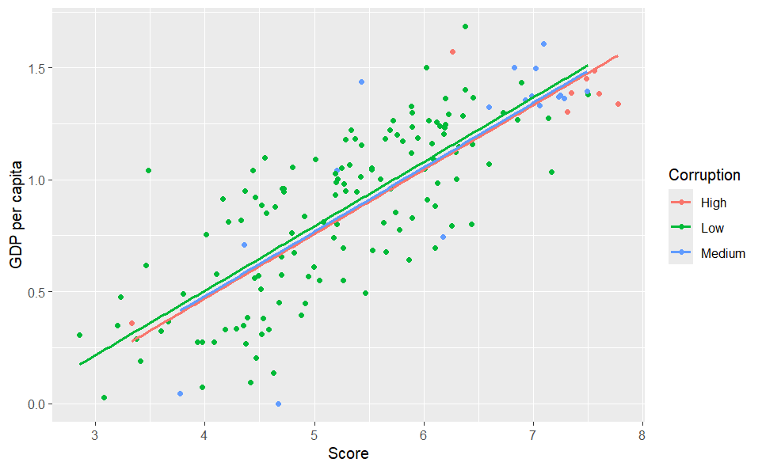

```r
plot_model_parallel_slopes <- HapinessReport %>%
  ggplot(aes(x = Score, y = `GDP per capita`, color = Corruption)) +
  geom_point() +
  geom_parallel_slopes(se = FALSE)

plot_model_parallel_slopes
```

```r
# Fit regression model:
score_model_parallel_slopes <- lm(Score ~ `GDP per capita`  + Corruption , data = HapinessReport)
# Get regression table:
score_model_parallel_slopes %>% get_regression_table()
```

| term | estimate | std_error | statistic | p_value | lower_ci | upper_ci |
| --- | --- | --- | --- | --- | --- | --- |
| intercept | 4.206 | 0.291 | 14.459 | 0.000 | 3.632 | 4.781 |
| `GDP per capita` | 2.042 | 0.139 | 14.740 | 0.000 | 1.768 | 2.315 |
| Corruption: Low | -0.741 | 0.245 | -3.030 | 0.003 | -1.224 | -0.258 |
| Corruption: Medium | -0.233 | 0.280 | -0.832 | 0.407 | -0.785 | 0.320 |

### (b) Interaction model

```r
# Fit regression model:
score_model_interaction <- lm(Score ~ `GDP per capita` * Corruption, data = HapinessReport)

# Get regression table:
score_model_interaction %>% get_regression_table()
```

| term | estimate | std_error | statistic | p_value | lower_ci | upper_ci |
| --- | --- | --- | --- | --- | --- | --- |
| intercept | 2.450 | 0.847 | 2.894 | 0.004 | 0.777 | 4.124 |
| `GDP per capita` | 3.408 | 0.634 | 5.371 | 0.000 | 2.154 | 4.661 |
| Corruption: Low | 1.077 | 0.859 | 1.254 | 0.212 | -0.620 | 2.774 |
| Corruption: Medium | 1.571 | 0.941 | 1.670 | 0.097 | -0.288 | 3.429 |
| `GDP per capita`:CorruptionLow | -1.439 | 0.653 | -2.202 | 0.029 | -2.729 | -0.148 |
| `GDP per capita`:CorruptionMedium | -1.407 | 0.715 | -1.968 | 0.051 | -2.821 | 0.006 |

## 3. Residual analysis

We compute the observed values, fitted values, and residuals for the interaction model. Refer the visualisation in EDA using ggplot2.

### (i) Find information on individual observations

```r
regression_points <- score_model_interaction %>% get_regression_points()
regression_points
```

| ID | Score | GDP per capita | Corruption | Score_hat | residual |
| --- | --- | --- | --- | --- | --- |
| 1 | 7.769 | 1.340 | High | 7.017 | 0.752 |
| 2 | 7.600 | 1.383 | High | 7.163 | 0.437 |
| 3 | 7.554 | 1.488 | High | 7.521 | 0.033 |
| 4 | 7.494 | 1.380 | Low | 6.245 | 1.249 |
| 5 | 7.488 | 1.396 | Medium | 6.814 | 0.674 |
| 6 | 7.480 | 1.452 | High | 7.399 | 0.081 |
| 7 | 7.343 | 1.387 | High | 7.177 | 0.166 |
| 8 | 7.307 | 1.303 | High | 6.891 | 0.416 |
| 9 | 7.278 | 1.365 | Medium | 6.752 | 0.526 |
| 10 | 7.246 | 1.376 | Medium | 6.774 | 0.472 |

[output cut: 146 more lines]

### (ii) Compute sum of squared residuals

Next, let us compute the sum of squared residuals. The pair of *best-fitting lines* will minimise the sum of squared residuals out of all possible lines we can draw through the points.

```r
regression_points %>%
  mutate(squared_residuals = residual^2) %>%
  summarize(sum_of_squared_residuals = sum(squared_residuals))
```

| sum_of_squared_residuals |
| --- |
| 62.32871 |

### (iii) Compute regression summaries

Finally, get the regression summaries like $R^2$ and Mean Squared Error (MSE).

```r
score_model_interaction %>% get_regression_summaries()
```

| r_squared | adj_r_squared | mse | rmse | sigma | statistic | p_value | df | nobs |
| --- | --- | --- | --- | --- | --- | --- | --- | --- |
| 0.675 | 0.665 | 0.3995608 | 0.6321082 | 0.645 | 62.433 | 0 | 5 | 156 |